# 빅분기 실기 - DataQ 제공문제

Python

Pandas

Scikit-learn

Scipy

Author

Jinwon Lee

Published

May 14, 2023

> [DataQ 예시문제](https://dataq.goorm.io/exam/116674/%EC%B2%B4%ED%97%98%ED%95%98%EA%B8%B0/quiz/1)

```python
import ssl
ssl._create_default_https_context = ssl._create_unverified_context
```

## 작업형 1

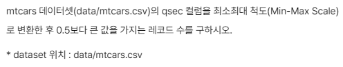

```python
import pandas as pd

mtcars = pd.read_csv('https://gist.githubusercontent.com/seankross/a412dfbd88b3db70b74b/raw/5f23f993cd87c283ce766e7ac6b329ee7cc2e1d1/mtcars.csv')

mtcars['qsec'] = (mtcars['qsec'] - min(mtcars['qsec'])) / (max(mtcars['qsec']) - min(mtcars['qsec']))
print(len(mtcars[mtcars['qsec'] > 0.5]))
```

```
9
```

## 작업형 2

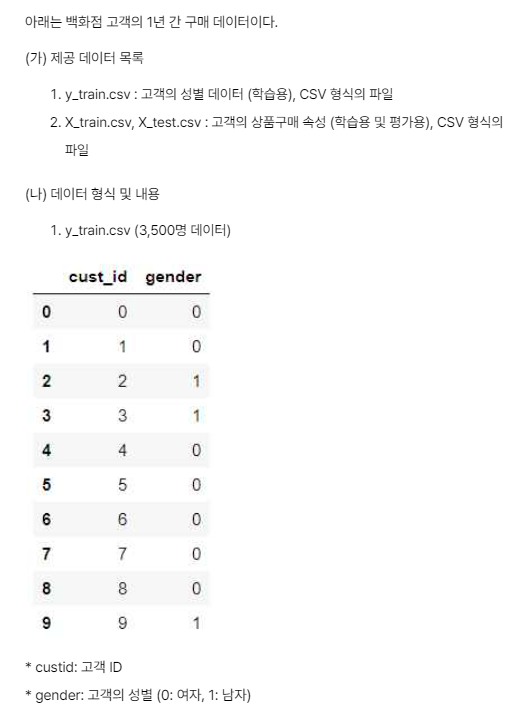

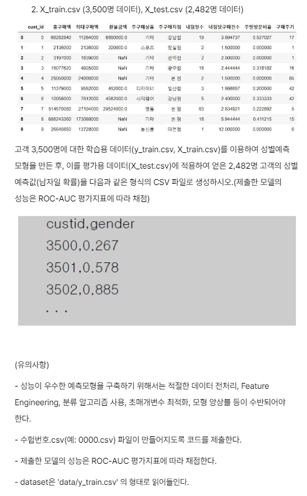

```python
import numpy as np
import pandas as pd

x_train = pd.read_csv('https://ndisk2.youngjin.com/cd/bigdata/quiz2/X_train.csv')
y_train = pd.read_csv('https://ndisk2.youngjin.com/cd/bigdata/quiz2/y_train.csv')
x_test = pd.read_csv('https://ndisk2.youngjin.com/cd/bigdata/quiz2/X_test.csv')

display(x_train.describe(include = 'object'), x_train.describe(exclude = 'object'))
```

|  | 주구매상품 | 주구매지점 |
| --- | --- | --- |
| count | 3500 | 3500 |
| unique | 42 | 24 |
| top | 기타 | 본 점 |
| freq | 595 | 1077 |

|  | cust_id | 총구매액 | 최대구매액 | 환불금액 | 내점일수 | 내점당구매건수 | 주말방문비율 | 구매주기 |
| --- | --- | --- | --- | --- | --- | --- | --- | --- |
| count | 3500.000000 | 3.500000e+03 | 3.500000e+03 | 1.205000e+03 | 3500.000000 | 3500.000000 | 3500.000000 | 3500.000000 |
| mean | 1749.500000 | 9.191925e+07 | 1.966424e+07 | 2.407822e+07 | 19.253714 | 2.834963 | 0.307246 | 20.958286 |
| std | 1010.507298 | 1.635065e+08 | 3.199235e+07 | 4.746453e+07 | 27.174942 | 1.912368 | 0.289752 | 24.748682 |
| min | 0.000000 | -5.242152e+07 | -2.992000e+06 | 5.600000e+03 | 1.000000 | 1.000000 | 0.000000 | 0.000000 |
| 25% | 874.750000 | 4.747050e+06 | 2.875000e+06 | 2.259000e+06 | 2.000000 | 1.666667 | 0.027291 | 4.000000 |
| 50% | 1749.500000 | 2.822270e+07 | 9.837000e+06 | 7.392000e+06 | 8.000000 | 2.333333 | 0.256410 | 13.000000 |
| 75% | 2624.250000 | 1.065079e+08 | 2.296250e+07 | 2.412000e+07 | 25.000000 | 3.375000 | 0.448980 | 28.000000 |
| max | 3499.000000 | 2.323180e+09 | 7.066290e+08 | 5.637530e+08 | 285.000000 | 22.083333 | 1.000000 | 166.000000 |

```python
from sklearn.preprocessing import LabelEncoder
from sklearn.model_selection import train_test_split

# 결측치 처리
x_train['환불금액'] = x_train['환불금액'].fillna(0)
x_test['환불금액'] = x_test['환불금액'].fillna(0)

# Label Encoding
for col in x_train.select_dtypes(include = 'object').columns :
    le = LabelEncoder()
    x_train[col] = le.fit_transform(x_train[col])
    x_test[col] = le.transform(x_test[col])
print('Done.')

# Train / Valid Split
X_train, X_valid, y_train, y_valid = train_test_split(x_train.drop(columns = 'cust_id'), y_train['gender'],
                                                      test_size = 0.1, random_state = 42)
print(X_train.shape, X_valid.shape, y_train.shape, y_valid.shape)
```

```
Done.
(3150, 9) (350, 9) (3150,) (350,)
```

```python
import sklearn
from sklearn.ensemble import *
from sklearn.metrics import roc_auc_score

# ensemble 모듈 내 Classifier 추출
clf = [model for model in dir(sklearn.ensemble) if model.endswith('Classifier')]

# Model Fitting
ab_clf = AdaBoostClassifier(random_state = 42).fit(X_train, y_train)
bg_clf = BaggingClassifier(random_state = 42).fit(X_train, y_train)
et_clf = ExtraTreesClassifier(random_state = 42).fit(X_train, y_train)
gb_clf = GradientBoostingClassifier(random_state = 42).fit(X_train, y_train)
hg_clf = HistGradientBoostingClassifier(random_state = 42).fit(X_train, y_train)
rf_clf = RandomForestClassifier(random_state = 42).fit(X_train, y_train)

estimators = [('ab', ab_clf), ('bg', bg_clf), ('et', et_clf), ('gb', gb_clf), ('hg', hg_clf), ('rf', rf_clf)]
st_clf = StackingClassifier(estimators).fit(X_train, y_train)
vt_clf = VotingClassifier(estimators).fit(X_train, y_train)

# ROC-AUC Score 계산
score_list = []
for model in [ab_clf, bg_clf, et_clf, gb_clf, hg_clf, rf_clf, st_clf, vt_clf] :
    score = np.round(roc_auc_score(model.predict(X_valid), y_valid), 4)
    score_list.append(score)

result = pd.DataFrame(data = score_list, index = clf, columns = ['ROC-AUC Score'])
result.sort_values(by = 'ROC-AUC Score', ascending = False, inplace = True)
print(f'Best Model : {result.idxmax().values} / ROC-AUC Score : {result.loc[result.idxmax(), "ROC-AUC Score"].values}')
result
```

```
Best Model : ['StackingClassifier'] / ROC-AUC Score : [0.6551]
```

|  | ROC-AUC Score |
| --- | --- |
| StackingClassifier | 0.6551 |
| GradientBoostingClassifier | 0.6538 |
| VotingClassifier | 0.6498 |
| RandomForestClassifier | 0.6365 |
| ExtraTreesClassifier | 0.6309 |
| HistGradientBoostingClassifier | 0.6280 |
| AdaBoostClassifier | 0.6277 |
| BaggingClassifier | 0.5667 |

```python
# Prediction
pred = st_clf.predict_proba(x_test.drop(columns = 'cust_id'))[:, 1]
pred_df = pd.DataFrame({'cust_id' : x_test['cust_id'], 'gender' : pred}) # .to_csv('000000000.csv', index = False)
display(pred_df)
```

|  | cust_id | gender |
| --- | --- | --- |
| 0 | 3500 | 0.436304 |
| 1 | 3501 | 0.240343 |
| 2 | 3502 | 0.189089 |
| 3 | 3503 | 0.390069 |
| 4 | 3504 | 0.439939 |
| ... | ... | ... |
| 2477 | 5977 | 0.578960 |
| 2478 | 5978 | 0.535448 |
| 2479 | 5979 | 0.462661 |
| 2480 | 5980 | 0.353368 |
| 2481 | 5981 | 0.538322 |

2482 rows × 2 columns

## 작업형 3

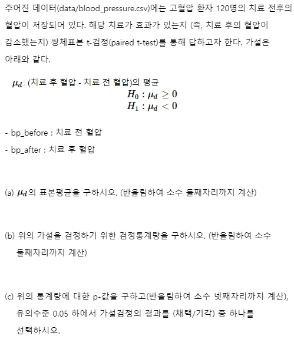

### 문제 설명

$\mu_a$ = **치료 후** 혈압의 평균

$\mu_b$ = **치료 전** 혈압의 평균

$\mu_d$ = (**치료 후** 혈압 - **치료 전** 혈압)의 평균

⇒ $\mu_d = \mu_a - \mu_b$

> - 귀무가설($H_0$) : $\mu_d = \mu_a - \mu_b \geq 0$
> - 대립가설($H_1$) : $\mu_d = \mu_a - \mu_b < 0$

`scipy.stats.ttest_rel` : 대응표본 t-검정 시 사용 - `alternative` : 대립가설($H_1$) 정의하는 파라미터 - `two-sided` : $\mu_d \neq 0$ $(\mu_a \neq \mu_b)$ ⇒ 분포의 **평균이 같지 않다.** - `less` : $\mu_d < 0$ $(\mu_a < \mu_b)$ ⇒ 첫 번째 표본분포의 평균이 두 번째 표본분포의 평균보다 **작다.** - `greater` : $\mu_d > 0$ $(\mu_a > \mu_b)$ ⇒ 첫 번째 표본분포의 평균이 두 번째 표본분포의 평균보다 **크다.**

```python
pressure = pd.read_csv('https://raw.githubusercontent.com/Opensourcefordatascience/Data-sets/master/blood_pressure.csv')
pressure.head()
```

|  | patient | sex | agegrp | bp_before | bp_after |
| --- | --- | --- | --- | --- | --- |
| 0 | 1 | Male | 30-45 | 143 | 153 |
| 1 | 2 | Male | 30-45 | 163 | 170 |
| 2 | 3 | Male | 30-45 | 153 | 168 |
| 3 | 4 | Male | 30-45 | 153 | 142 |
| 4 | 5 | Male | 30-45 | 146 | 141 |

### ① $\mu_d$의 표본평균을 입력하시오. (반올림하여 소수 둘째자리까지 계산)

```python
pressure['diff'] = pressure['bp_after'] - pressure['bp_before']

# 쌍체표본 검정의 경우 표본평균을 구할 때 (n-1)로 나누는 것이 아닌 n으로 나누어 줌
avg = sum(pressure['diff']) / len(pressure['diff'])
print(f'{avg :.2f}')
```

```
-5.09
```

```python
from scipy.stats import shapiro, ttest_rel

# 정규성 검정 > pvalue = 0.784이므로 정규성을 띈다.
# shapiro(pressure['diff'])

statistic, pvalue = ttest_rel(pressure['bp_after'], pressure['bp_before'], alternative = 'less')
print(f'{statistic :.4f}')
```

```
-3.3372
```

### ③ 위의 통계량에 대한 p-값을 구하여 입력하시오. (반올림하여 소수 넷째자리까지 계산)

```python
print(f'{pvalue :.4f}')
```

```
0.0006
```

### ④ 유의수준 0.05 하에서 귀무가설을 기준으로 검정의 결과를 (채택/기각) 중 선택하여 입력하시오.

```python
print('기각' if pvalue < 0.05 else '채택')
```

```
기각
```

## Tip

### `dir` 함수 사용

```python
import scipy.stats
print([module for module in dir(scipy.stats) if module[0] != '_'])
```

```
['BootstrapDegenerateDistributionWarning', 'F_onewayBadInputSizesWarning', 'F_onewayConstantInputWarning', 'NumericalInverseHermite', 'PearsonRConstantInputWarning', 'PearsonRNearConstantInputWarning', 'SpearmanRConstantInputWarning', 'alexandergovern', 'alpha', 'anderson', 'anderson_ksamp', 'anglit…
```

### `help` 함수 사용

```python
print(help(scipy.stats.ttest_rel))
```

```
Help on function ttest_rel in module scipy.stats._stats_py:

ttest_rel(a, b, axis=0, nan_policy='propagate', alternative='two-sided')
    Calculate the t-test on TWO RELATED samples of scores, a and b.

    This is a test for the null hypothesis that two related or
    repeated samples have identical average (expected) values.

    Parameters
    ----------
    a, b : array_like
        The arrays must have the same shape.
    axis : int or None, optional
        Axis along which to compute test. If None, compute over the whole
        arrays, `a`, and `b`.
    nan_policy : {'propagate', 'raise', 'omit'}, optional
        Defines how to handle when input contains nan.
        The following options are available (default is 'propagate'):

          * 'propagate': returns nan
          * 'raise': throws an error
          * 'omit': performs the calculations ignoring nan values
    alternative : {'two-sided', 'less', 'greater'}, optional
        Defines the alternative hypothesis.
        The following options are available (default is 'two-sided'):

        * 'two-sided': the means of the distributions underlying the samples
          are unequal.
        * 'less': the mean of the distribution underlying the first sample
          is less than the mean of the distribution underlying the second
          sample.
        * 'greater': the mean of the distribution underlying the first
          sample is greater than the mean of the distribution underlying
          the second sample.

        .. versionadded:: 1.6.0

    Returns
    -------
    statistic : float or array
```

[output cut: 21 more lines]

```
    --------
    >>> from scipy import stats
    >>> rng = np.random.default_rng()

    >>> rvs1 = stats.norm.rvs(loc=5, scale=10, size=500, random_state=rng)
    >>> rvs2 = (stats.norm.rvs(loc=5, scale=10, size=500, random_state=rng)
    ...         + stats.norm.rvs(scale=0.2, size=500, random_state=rng))
    >>> stats.ttest_rel(rvs1, rvs2)
    Ttest_relResult(statistic=-0.4549717054410304, pvalue=0.6493274702088672)
    >>> rvs3 = (stats.norm.rvs(loc=8, scale=10, size=500, random_state=rng)
    ...         + stats.norm.rvs(scale=0.2, size=500, random_state=rng))
    >>> stats.ttest_rel(rvs1, rvs3)
    Ttest_relResult(statistic=-5.879467544540889, pvalue=7.540777129099917e-09)

None
```